# Introduction to data analytics

Fani Apostolidou Kiouti

October, 2021

## Aggregating data, interchaning between formats to draw a forest plot

The example comes from a meta-analysis assessing the use of rectal indomethacin to prevent post-ERCP pancreatitis. The dataset is constructed to run with meta-analytic algorithmsand the primary outcome is binary; that means that the effect size in each study is the odds ratio between treatment and comparator. In this example we will merge two dataframes, select the variables needed to calculate odds ratio and confidence intervals, construct 2x2 tables and then rearrange our results before plotting them.

Our data lay into two separate sheets in the same file.

```r
library(magrittr)
library(dplyr)
library(ggplot2)
# Data import
library(readxl)
form <- read_excel("~/AUTh.MSc/meta.gr/form.xlsx",
                   sheet = "Methodology")
form_res <- read_excel("~/AUTh.MSc/meta.gr/form.xlsx")

# Merging data, base::merge()
metan <- merge(form, form_res, by = "ID")

# {dplyr} in use
metan %<>% # assignment pipe operator
  select(ID, ntreat, etreat, ncomp, ecomp)

metan
```

| ID | ntreat | etreat | ncomp | ecomp |
| --- | --- | --- | --- | --- |
| AndradeDavilaBMCG2015 | 78 | 4 | 67 | 17 |
| DobronteWJG2014 | 327 | 20 | 296 | 22 |
| ElmunzerNEJM2012 | 268 | 27 | 255 | 52 |
| HosseiniAIM2016 | 89 | 11 | 88 | 17 |
| LevenickG2016 | 207 | 16 | 215 | 11 |
| MontanoREED2007 | 71 | 4 | 63 | 12 |
| PataiJCGE2015 | 252 | 18 | 232 | 37 |
| SotoudehmaneshAJG2007 | 238 | 7 | 230 | 15 |

We need to construct 2x2 tables by study. A `lapply` function with a `split` function nested will do the trick. Remember, `lapply` can take all arguments needed after the FUN = … is set.

```r
nmeta <- lapply(split(metan[,2:5], metan$ID), matrix, nrow = 2, ncol = 2)
nmeta
```

```
## $AndradeDavilaBMCG2015
##      [,1] [,2]
## [1,] 78   67
## [2,] 4    17
##
## $DobronteWJG2014
##      [,1] [,2]
## [1,] 327  296
## [2,] 20   22
##
## $ElmunzerNEJM2012
##      [,1] [,2]
## [1,] 268  255
## [2,] 27   52
##
## $HosseiniAIM2016
##      [,1] [,2]
## [1,] 89   88
## [2,] 11   17
##
## $LevenickG2016
##      [,1] [,2]
## [1,] 207  215
## [2,] 16   11
##
## $MontanoREED2007
##      [,1] [,2]
## [1,] 71   63
## [2,] 4    12
##
## $PataiJCGE2015
##      [,1] [,2]
## [1,] 252  232
## [2,] 18   37
##
## $SotoudehmaneshAJG2007
##      [,1] [,2]
## [1,] 238  230
## [2,] 7    15
```

Our 2x2 tables are of the general form

| Pancreatitis | Indomethacin | Placebo |
| --- | --- | --- |
| No | `ntreat` | `ncomp` |
| Yes | `etreat` | `ecomp` |

```r
orcis <- function(x) {
  OR = (x[[1,1]]*x[[2,2]]) / (x[[2,1]]*x[[1,2]]) # inverting the fractions
  # Upper 95% confidence interval
  upci = exp(log(OR) +
               1.96/2*sqrt(1/x[[1,2]] + 1/x[[2,2]] + 1/x[[1,1]] + 1/x[[2,1]]))
  # Lower 95% confidence interval
  lwci = exp(log(OR) -
               1.96/2*sqrt(1/x[[1,2]] + 1/x[[2,2]] + 1/x[[1,1]] + 1/x[[2,1]]))
  # round() rounds up the digits of a numerical vector
  list(OR = round(OR, 2), LW95CI = round(lwci, 2), UP95CI = round(upci, 2))
}
```

Now we can `mapply` our list of matrices `nmeta` to create a list of all calculated values. In the attributes of the list you will find the study names as dimension names. To access them you will need to employ list indices, `[[]]`.

```r
odds <- mapply(orcis, nmeta) # new object, list
godds <- cbind(t(odds), study = dimnames(odds)[[2]]) # t() transposes the object
                                                     # converts rows to columns
                                                     # add a column with study
                                                     # names
grodds <- data.frame(apply(godds, 2, unlist)) # construct a dataframe after
                                              # unlisting all elements
                                              # in order to use them with ggplot
```

Use the `{ggplot}` functions to construct a forest plot.

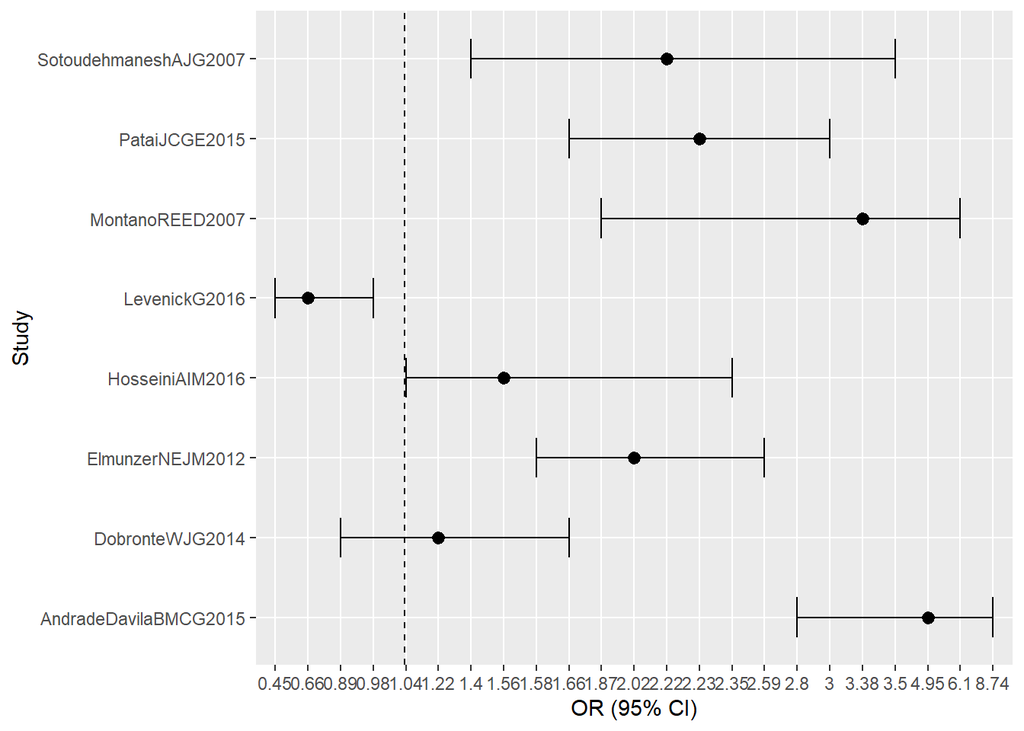

```r
mtn <- ggplot(grodds, aes(x = study, y = OR, ymin = LW95CI, ymax = UP95CI)) +
  geom_pointrange() +
  # the following line took some experimentation; yintercept is closest to OR = 1
  # in the fifth position in the axis, which is equal to 1.041.
  # So to place the line in OR = 1, subtract 5 - 0.041.
  geom_hline(yintercept = 5 - 0.041, linetype = 2) +
  geom_errorbar(aes(ymin = LW95CI, ymax = UP95CI),width = 0.5) +
  xlab("Study") +
  ylab("OR (95% CI)") +
  coord_flip()
mtn
```